# Inferencia en el modelo de regresión lineal: bootstrap

02 octubre 2019

# 1 Datos

Supongamos que conocemos:

```r
# y = a + bx + u, u ~ N(0,1)
a = 2
b = 0.5
sigma = 1
x = 1:20
```

Podemos simular la variable y:

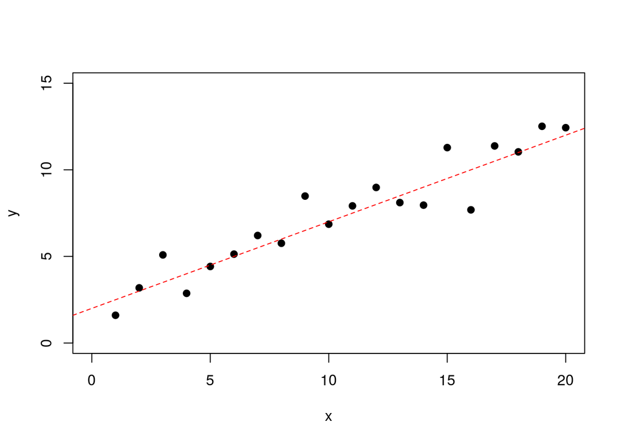

```r
set.seed(2) # para obtener siempre los mismos resultados
u = rnorm(20, 0, sigma)
# datos
y = a + b*x + u
# dibujamos los datos obtenidos (x,y)
plot(x,y, xlim = c(0,20), ylim = c(0,15), pch = 19)
# añadimos la recta "teórica" entre x e y
abline(a, b, lty = 2, lwd = 1, col = "red")
```

# 2 Precisión de los estimadores mediante probabilidad

Ya hemos visto que

$$\hat \beta \sim N(\beta, (X^TX)^{-1} \sigma^2)$$

Este resultado se deriva **matemáticamente** a partir de la distribución

$$\epsilon \sim N(0, \sigma^2 I)$$

Estimamos a y b utilizando x e y:

```r
m = lm(y ~ x)
(beta_e = coef(m))
```

```
## (Intercept)           x
##   2.0610497   0.5128011
```

Podemos dibujar la recta *estimada* y la *teórica*:

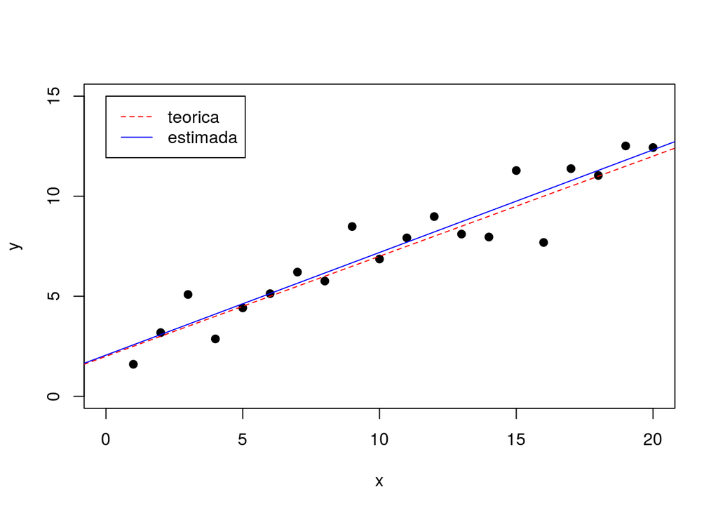

```r
plot(x,y, xlim = c(0,20), ylim = c(0,15), pch = 19)
abline(a, b, lty = 2, lwd = 1, col = "red")
abline(beta_e[1], beta_e[2], lwd = 1, col = "blue")
legend(0, 15, legend=c("teorica", "estimada"), col=c("red", "blue"), lty=c(2,1))
```

La varianza de los estimadores (o el standard error) es una manera de calcular su precisión:

```r
(beta_var = diag(vcov(m)))
```

```
## (Intercept)           x
## 0.253927377 0.001769529
```

Otra manera es mediante los intervalos de confianza:

```r
confint(m)
```

```
##                 2.5 %   97.5 %
## (Intercept) 1.0023697 3.119730
## x           0.4244242 0.601178
```

# 3 Precisión de los estimadores mediante simulaciones

Otra manera de obtener los resultados del apartado anterior es utilizando simulaciones en lugar de matemáticas. En este caso lo podemos hacer porque conocemos a, b y $\sigma$:

```r
beta_e_sim = matrix(0, nrow = 500, ncol = 2)
for (i in 1:500){
  ui = rnorm(20, 0, sigma)
  yi = a + b*x + ui
  mi = lm(yi ~ x)
  beta_e_sim[i,] = coef(mi)
}
```

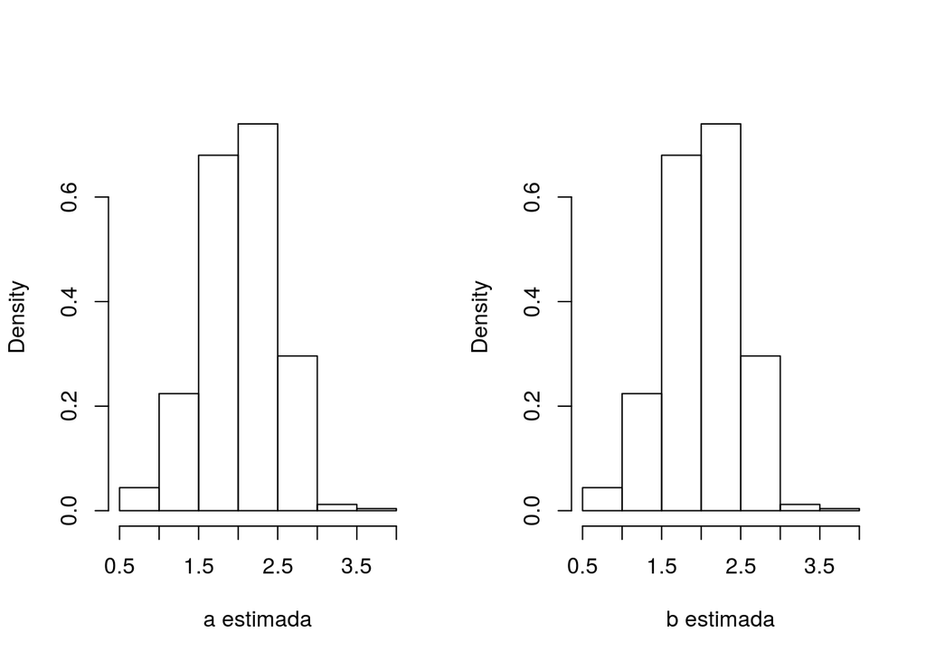

```r
par(mfrow = c(1,2))
hist(beta_e_sim[,1], freq = F, xlab = "a estimada", main = "")
hist(beta_e_sim[,1], freq = F, xlab = "b estimada", main = "")
```

EL valor final que elegimos para $\hat a$ y $\hat b$ es la media de los datos:

```r
apply(beta_e_sim, 2, mean)
```

```
## [1] 2.0211790 0.4990019
```

La varianza de los estimadores es la varianza de los datos correspondientes:

```r
apply(beta_e_sim, 2, var)
```

```
## [1] 0.21604665 0.00151284
```

El intervalo de confianza se puede calcular a partir de los cuantiles de la distribución:

```r
apply(beta_e_sim, 2, quantile, probs = c(0.025,0.975))
```

```
##           [,1]      [,2]
## 2.5%  1.053055 0.4207785
## 97.5% 2.859275 0.5744381
```

# 4 Precisión de los estimadores mediante bootstrap

El problema con el método de simulaciones es que se tiene que conocer {a, b, $\sigma$}, y eso nunca ocurre. En la práctica solo se conoce {$x_i, y_i$}. Una alternativa es utilizar el método bootstrap:

```r
# residuos
e = resid(m)
# muestreamos los residuos CON REPOSICION
beta_e_b = matrix(0, nrow = 500, ncol = 2)
for (i in 1:500){
  eb = sample(e, rep = T)
  yb = beta_e[1] + beta_e[2]*x + eb
  mb = lm(yb ~ x)
  beta_e_b[i,] = coef(mb)
}
```

Podemos calcular la varianza de los estimadores como:

```r
apply(beta_e_b, 2, var)
```

```
## [1] 0.23774930 0.00159955
```

Y los intervalos de confianza:

```r
apply(beta_e_b, 2, quantile, probs = c(0.025,0.975))
```

```
##           [,1]      [,2]
## 2.5%  1.048589 0.4388716
## 97.5% 2.929364 0.5975489
```

El método bootstrap cobra importancia cuando la distribución en el muestreo teórica no se puede calcular matemáticamente.

# 5 Ejemplo

Vamos a calcular la precisión de los parámetros del modelo siguiente utilizando probabilidad y bootstrap:

```r
d = faraway::gala
m1 = lm(Species ~ Area + Elevation + Nearest + Scruz + Adjacent, data = d)
beta_e = coef(m1)
```

```r
# BOOTSTRAP
# residuos
e = resid(m1)
# matrix de las X
X = model.matrix(m1)
# muestreamos los residuos CON REPOSICION
beta_e_b = matrix(0, nrow = 500, ncol = 6)
for (i in 1:500){
  eb = sample(e, rep = T)
  yb = X %*% beta_e + eb
  mb = lm(yb ~ Area + Elevation + Nearest + Scruz + Adjacent, data = d)
  beta_e_b[i,] = coef(mb)
}
```

- Varianza de los parémetros estimados

```r
# con probabilidad
diag(vcov(m1))
```

```
##  (Intercept)         Area    Elevation      Nearest        Scruz
## 3.668833e+02 5.027618e-04 2.879697e-03 1.111203e+00 4.639813e-02
##     Adjacent
## 3.132967e-04
```

```r
# con bootstrap
apply(beta_e_b, 2, var)
```

```
## [1] 2.857035e+02 4.113618e-04 2.472941e-03 9.982770e-01 4.040625e-02
## [6] 2.799286e-04
```

- intervalos de confianza

```r
# con probabilidad
confint(m1)
```

```
##                   2.5 %      97.5 %
## (Intercept) -32.4641006 46.60054205
## Area         -0.0702158  0.02233912
## Elevation     0.2087102  0.43021935
## Nearest      -2.1664857  2.18477363
## Scruz        -0.6850926  0.20404416
## Adjacent     -0.1113362 -0.03827344
```

```r
# con bootstrap
t(apply(beta_e_b, 2, quantile, probs = c(0.025,0.975)))
```

```
##              2.5%       97.5%
## [1,] -24.42202493 38.76288849
## [2,]  -0.06102367  0.02540897
## [3,]   0.22562407  0.42286039
## [4,]  -1.70054626  2.31979901
## [5,]  -0.61829317  0.15621835
## [6,]  -0.10266255 -0.03516742
```